# Process Simulation Results Solve for Discrete Optimal Allocation

# Analyze Planner Value

## Process Simulation Outputs

### Variable Names and Paths

```r
# File Path
srt_simu_path <- 'C:/Users/fan/Documents/Dropbox (UH-ECON)/PrjNygaardSorensenWang/Output/'
# File Name
snm_simu_csv <- 'snwx_v_planner_small.csv'
# Column Names
ar_svr_csv <- c('age', 'marital', 'kids', 'checks', 'ymin', 'ymax', 'mass', 'survive', 'vtilde', 'ctilde')
# Variables That Identify Individual Types
ar_svr_groups <- c('age', 'marital', 'kids', 'ymin', 'ymax')
ar_svr_groups_stats <- c('mass', 'survive')
# Number of Checks and Planner Value
svr_checks <- 'checks'
svr_v_value <- 'vtilde'
svr_c_value <- 'ctilde'
```

### Read Input CSV Data

```r
mt_plan_v_tilde <- read.csv(paste0(srt_simu_path, snm_simu_csv), header=FALSE)
df_plan_v_tilde <- as_tibble(mt_plan_v_tilde) %>%
  rename_all(~c(ar_svr_csv)) %>%
  rowid_to_column(var = "id") %>%
  filter(vtilde != 0)

# Column 1: Age (in year before COVID)
# Column 2: Marital status (0 if not married; 1 if married)
# Column 3: Nr of kids (0, 1, ..., 5) where 5 means 5 or more
# Column 4: Number of welfare checks (here either equal to 0 or 1)
# Column 5 and column 6 give income range
# So the individual's income is at least as large as the value in column 5 but strictly less than the value in column 6
# Column 7: Population weight Of that particular group (in the stationary distribution)
# Column 8: Survival probability of that particular age (since the planner knows that some of the individuals will die before next period, so wasn't sure how you wanted me to include that. I did not already include it in V^tilde)
# Column 9: Value of planner as in the slides (with the exception that I didn't multiply by the survival probability
```

```r
REconTools::ff_summ_percentiles(df_plan_v_tilde)
```

```
attributes are not identical across measure variables;
they will be dropped
```

| stats | age | checks | ctilde | id | kids | marital | mass | survive | vtilde | ymax | ymin |
| --- | --- | --- | --- | --- | --- | --- | --- | --- | --- | --- | --- |
| n | 191046 | 191046 | 191046 | 191046 | 191046 | 191046 | 191046 | 191046 | 191046 | 191046 | 191046 |
| unique | 17 | 51 | 187515 | 191046 | 3 | 2 | 3703 | 17 | 189533 | 1 | 158 |
| NAobs | 0 | 0 | 0 | 0 | 0 | 0 | 0 | 0 | 0 | 0 | 0 |
| ZEROobs | 0 | 3746 | 0 | 0 | 64515 | 99348 | 0 | 0 | 0 | 0 | 0 |
| mean | 2.597784e+01 | 2.500000e+01 | 1.661324e+00 | 9.552350e+04 | 9.946610e-01 | 4.799786e-01 | 2.667869e-04 | 2.008267e+00 | -1.099456e+00 | 1.000000e+31 | 1.317829e+05 |
| sd | 3.568692e+00 | 1.471964e+01 | 9.789679e-01 | 5.515037e+04 | 8.185494e-01 | 4.996003e-01 | 7.341167e-04 | 5.933304e-01 | 2.599145e+00 | 0.000000e+00 | 7.236255e+04 |
| cv | 0.1373744 | 0.5887856 | 0.5892699 | 0.5773488 | 0.8229431 | 1.0408803 | 2.7516969 | 0.2954441 | -2.3640278 | 0.0000000 | 0.5491044 |
| min | 1.800000e+01 | 0.000000e+00 | 2.170736e-01 | 1.000000e+00 | 0.000000e+00 | 0.000000e+00 | 1.395051e-49 | -5.772157e-01 | -1.755908e+01 | 1.000000e+31 | 2.438352e+04 |
| p01 | 1.800000e+01 | 0.000000e+00 | 3.021847e-01 | 1.911450e+03 | 0.000000e+00 | 0.000000e+00 | 5.006923e-35 | -5.772157e-01 | -9.741661e+00 | 1.000000e+31 | 3.454332e+04 |
| p05 | 2.000000e+01 | 2.000000e+00 | 4.901908e-01 | 9.553250e+03 | 0.000000e+00 | 0.000000e+00 | 1.908171e-20 | 9.227843e-01 | -6.340533e+00 | 1.000000e+31 | 4.063920e+04 |

[output cut: 8 more lines]

### Generate ID dataframe, and Value dataframe using Group IDs

```r
# group id
svr_group_id <- 'group_id'
# Define
ls_svr_group_vars <- ar_svr_groups
# panel dataframe following
df_plan_v_tilde_id <- df_plan_v_tilde %>%
  arrange(!!!syms(ls_svr_group_vars)) %>%
  group_by(!!!syms(ls_svr_group_vars)) %>%
  mutate(!!sym(svr_group_id) := (row_number()==1)*1) %>%
  ungroup() %>%
  mutate(!!sym(svr_group_id) := cumsum(!!sym(svr_group_id))) %>%
  select(one_of(svr_group_id, ls_svr_group_vars), everything())
```

Stats Check:

```r
# Stats
# REconTools::ff_summ_count_unique_by_groups(
#   df_plan_v_tilde_id,ls_svr_group_vars,svr_group_id)
# REconTools::ff_summ_percentiles(df_plan_v_tilde_id, bl_statsasrows = FALSE)
```

ID Identifying Dataframe

```r
# Select Grouping by Variables
df_id <- df_plan_v_tilde_id %>%
  select(one_of(svr_group_id, ls_svr_group_vars, ar_svr_groups_stats)) %>%
  group_by(!!!syms(svr_group_id)) %>%
  slice_head() %>% ungroup() %>%
  select(one_of(svr_group_id, ls_svr_group_vars, ar_svr_groups_stats)) %>%
  rename(id_i = !!sym(svr_group_id))
ar_group_ids <- unique(df_id %>% pull(id_i))
# Summarize
REconTools::ff_summ_percentiles(df_id)
```

```
attributes are not identical across measure variables;
they will be dropped
```

| stats | age | id.i | kids | marital | mass | survive | ymax | ymin |
| --- | --- | --- | --- | --- | --- | --- | --- | --- |
| n | 3746 | 3746 | 3746 | 3746 | 3746 | 3746 | 3746 | 3746 |
| unique | 17 | 3746 | 3 | 2 | 3703 | 17 | 1 | 158 |
| NAobs | 0 | 0 | 0 | 0 | 0 | 0 | 0 | 0 |
| ZEROobs | 0 | 0 | 1265 | 1948 | 0 | 0 | 0 | 0 |
| mean | 2.597784e+01 | 1.873500e+03 | 9.946610e-01 | 4.799786e-01 | 2.667869e-04 | 2.008267e+00 | 1.000000e+31 | 1.317829e+05 |
| sd | 3.569159e+00 | 1.081521e+03 | 8.186565e-01 | 4.996657e-01 | 7.342128e-04 | 5.934081e-01 | 0.000000e+00 | 7.237202e+04 |
| cv | 0.1373924 | 0.5772732 | 0.8230508 | 1.0410165 | 2.7520571 | 0.2954827 | 0.0000000 | 0.5491763 |
| min | 1.800000e+01 | 1.000000e+00 | 0.000000e+00 | 0.000000e+00 | 1.395051e-49 | -5.772157e-01 | 1.000000e+31 | 2.438352e+04 |
| p01 | 1.800000e+01 | 3.845000e+01 | 0.000000e+00 | 0.000000e+00 | 5.657328e-35 | -5.772157e-01 | 1.000000e+31 | 3.454332e+04 |
| p05 | 2.000000e+01 | 1.882500e+02 | 0.000000e+00 | 0.000000e+00 | 1.936111e-20 | 9.227843e-01 | 1.000000e+31 | 4.063920e+04 |

[output cut: 8 more lines]

```r
# Select 4 variables
df_value <- df_plan_v_tilde_id %>%
  select(one_of(svr_group_id, svr_checks, svr_v_value, svr_c_value))
# Summarize
REconTools::ff_summ_percentiles(df_value)
```

```
attributes are not identical across measure variables;
they will be dropped
```

| stats | checks | ctilde | group.id | vtilde |
| --- | --- | --- | --- | --- |
| n | 191046 | 191046 | 191046 | 191046 |
| unique | 51 | 187515 | 3746 | 189533 |
| NAobs | 0 | 0 | 0 | 0 |
| ZEROobs | 3746 | 0 | 0 | 0 |
| mean | 25.000000 | 1.661324 | 1873.500000 | -1.099456 |
| sd | 14.7196400 | 0.9789679 | 1081.3798458 | 2.5991446 |
| cv | 0.5887856 | 0.5892699 | 0.5771977 | -2.3640278 |
| min | 0.0000000 | 0.2170736 | 1.0000000 | -17.5590751 |
| p01 | 0.0000000 | 0.3021847 | 38.0000000 | -9.7416614 |
| p05 | 2.0000000 | 0.4901908 | 188.0000000 | -6.3405327 |

[output cut: 8 more lines]

```r
# REconTools::ff_summ_count_unique_by_groups(df_value, svr_group_id, svr_group_id)
```

## Generate Dataframe Inputs for the Allocation Problem

Restructure the value dataframe slightly so that it can be used with the allocation functions. Note that the output structure has an *A* column and an *alpha* column, and starts counting *checks* at 1. For the check = 1 row, *A* is the value without the check, and *alpha* is the marginal effects of the checks.

### Generate IL Dataframe Core

```r
# 1. id column and id_il
df_il <- df_value %>% rename(id_i = !!sym(svr_group_id)) %>%
  mutate(id_il = row_number()) %>%
  select(id_i, id_il, everything())
# 2. D_max_i and D_il
df_il <- df_il %>%
  arrange(id_i, svr_checks) %>% group_by(id_i) %>%
  mutate(D_max_i = n()) %>%
  rename(D_il = !!sym(svr_checks)) %>%
  mutate(beta_i = 1/n()) %>%
  select(id_i, id_il, D_max_i, D_il, everything())
# Summarize
REconTools::ff_summ_percentiles(df_il)
```

```
attributes are not identical across measure variables;
they will be dropped
```

| stats | beta.i | ctilde | D.il | D.max.i | id.i | id.il | vtilde |
| --- | --- | --- | --- | --- | --- | --- | --- |
| n | 191046 | 191046 | 191046 | 191046 | 191046 | 191046 | 191046 |
| unique | 1 | 187515 | 51 | 1 | 3746 | 191046 | 189533 |
| NAobs | 0 | 0 | 0 | 0 | 0 | 0 | 0 |
| ZEROobs | 0 | 0 | 3746 | 0 | 0 | 0 | 0 |
| mean | 1.960784e-02 | 1.661324e+00 | 2.500000e+01 | 5.100000e+01 | 1.873500e+03 | 9.552350e+04 | -1.099456e+00 |
| sd | 0.000000e+00 | 9.789679e-01 | 1.471964e+01 | 0.000000e+00 | 1.081380e+03 | 5.515037e+04 | 2.599145e+00 |
| cv | 0.0000000 | 0.5892699 | 0.5887856 | 0.0000000 | 0.5771977 | 0.5773488 | -2.3640278 |
| min | 0.01960784 | 0.21707357 | 0.00000000 | 51.00000000 | 1.00000000 | 1.00000000 | -17.55907505 |
| p01 | 0.01960784 | 0.30218472 | 0.00000000 | 51.00000000 | 38.00000000 | 1911.45000000 | -9.74166143 |
| p05 | 0.01960784 | 0.49019082 | 2.00000000 | 51.00000000 | 188.00000000 | 9553.25000000 | -6.34053270 |

[output cut: 8 more lines]

### Generate IL Dataframe for Utility

Generate A and alpha:

```r
# 3. A_il and alpha_il
df_il_U <- df_il %>%
  mutate(c_alpha_il = lead(!!sym(svr_c_value)) - (!!sym(svr_c_value)),
         v_alpha_il = lead(!!sym(svr_v_value)) - (!!sym(svr_v_value))) %>%
  rename(c_A_il = !!sym(svr_c_value),
         v_A_il = !!sym(svr_v_value)) %>%
  ungroup()

# 4. drop max check
df_il_U <- df_il_U %>%
  filter(D_il != max(df_il$D_il)) %>%
  mutate(D_il = D_il + 1)
```

Summarize:

```r
# https://fanwangecon.github.io/PrjOptiAlloc/reference/df_opt_caschool_input_il.html
# id_i id_il D_max_i  D_il  A_il alpha_il  beta_i
head(df_il_U, 50)
```

| id_i | id_il | D_max_i | D_il | v_A_il | c_A_il | beta_i | c_alpha_il | v_alpha_il |
| --- | --- | --- | --- | --- | --- | --- | --- | --- |
| 1 | 1 | 51 | 1 | -10.381750 | 0.2803800 | 0.01960784 | 0.001721885 | 0.02411716 |
| 1 | 2 | 51 | 2 | -10.357633 | 0.2821019 | 0.01960784 | 0.001721885 | 0.02411716 |
| 1 | 3 | 51 | 3 | -10.333515 | 0.2838238 | 0.01960784 | 0.001721885 | 0.02411716 |
| 1 | 4 | 51 | 4 | -10.309398 | 0.2855457 | 0.01960784 | 0.001721885 | 0.02411716 |
| 1 | 5 | 51 | 5 | -10.285281 | 0.2872676 | 0.01960784 | 0.001721885 | 0.02411716 |
| 1 | 6 | 51 | 6 | -10.261164 | 0.2889894 | 0.01960784 | 0.001721885 | 0.02411716 |
| 1 | 7 | 51 | 7 | -10.237047 | 0.2907113 | 0.01960784 | 0.001654930 | 0.02223905 |
| 1 | 8 | 51 | 8 | -10.214808 | 0.2923663 | 0.01960784 | 0.001512714 | 0.01817667 |
| 1 | 9 | 51 | 9 | -10.196631 | 0.2938790 | 0.01960784 | 0.001513921 | 0.01819276 |
| 1 | 10 | 51 | 10 | -10.178438 | 0.2953929 | 0.01960784 | 0.001512848 | 0.01817846 |

[output cut: 40 more lines]

```r
tail(df_il_U, 50)
```

| id_i | id_il | D_max_i | D_il | v_A_il | c_A_il | beta_i | c_alpha_il | v_alpha_il |
| --- | --- | --- | --- | --- | --- | --- | --- | --- |
| 3746 | 190996 | 51 | 1 | -0.3014083 | 1.397482 | 0.01960784 | 0.001721764 | 0.001070529 |
| 3746 | 190997 | 51 | 2 | -0.3003378 | 1.399203 | 0.01960784 | 0.001721764 | 0.001070529 |
| 3746 | 190998 | 51 | 3 | -0.2992672 | 1.400925 | 0.01960784 | 0.001721764 | 0.001070529 |
| 3746 | 190999 | 51 | 4 | -0.2981967 | 1.402647 | 0.01960784 | 0.001721764 | 0.001070529 |
| 3746 | 191000 | 51 | 5 | -0.2971262 | 1.404369 | 0.01960784 | 0.001721764 | 0.001070529 |
| 3746 | 191001 | 51 | 6 | -0.2960557 | 1.406090 | 0.01960784 | 0.001721764 | 0.001070529 |
| 3746 | 191002 | 51 | 7 | -0.2949851 | 1.407812 | 0.01960784 | 0.001721764 | 0.001070529 |
| 3746 | 191003 | 51 | 8 | -0.2939146 | 1.409534 | 0.01960784 | 0.001721764 | 0.001070529 |
| 3746 | 191004 | 51 | 9 | -0.2928441 | 1.411256 | 0.01960784 | 0.001722374 | 0.001070941 |
| 3746 | 191005 | 51 | 10 | -0.2917731 | 1.412978 | 0.01960784 | 0.001721831 | 0.001070575 |

[output cut: 40 more lines]

```r
# Summarize
REconTools::ff_summ_percentiles(df_il_U)
```

```
attributes are not identical across measure variables;
they will be dropped
```

| stats | beta.i | c.A.il | c.alpha.il | D.il | D.max.i | id.i | id.il | v.A.il | v.alpha.il |
| --- | --- | --- | --- | --- | --- | --- | --- | --- | --- |
| n | 187300 | 187300 | 187300 | 187300 | 187300 | 187300 | 187300 | 187300 | 187300 |
| unique | 1 | 183835 | 57357 | 50 | 1 | 3746 | 187300 | 185818 | 60755 |
| NAobs | 0 | 0 | 0 | 0 | 0 | 0 | 0 | 0 | 0 |
| ZEROobs | 0 | 0 | 0 | 0 | 0 | 0 | 0 | 0 | 0 |
| mean | 1.960784e-02 | 1.661011e+00 | 6.284343e-04 | 2.550000e+01 | 5.100000e+01 | 1.873500e+03 | 9.552300e+04 | -1.100691e+00 | 2.494639e-03 |
| sd | 0.000000e+00 | 9.790199e-01 | 3.982653e-04 | 1.443091e+01 | 0.000000e+00 | 1.081380e+03 | 5.515038e+04 | 2.600625e+00 | 4.203825e-03 |
| cv | 0.0000000 | 0.5894121 | 0.6337421 | 0.5659180 | 0.0000000 | 0.5771977 | 0.5773518 | -2.3627204 | 1.6851434 |
| min | 1.960784e-02 | 2.170736e-01 | 4.955896e-05 | 1.000000e+00 | 5.100000e+01 | 1.000000e+00 | 1.000000e+00 | -1.755908e+01 | 4.253845e-05 |
| p01 | 1.960784e-02 | 3.014727e-01 | 1.933013e-04 | 1.000000e+00 | 5.100000e+01 | 3.800000e+01 | 1.910990e+03 | -9.745701e+00 | 7.632857e-05 |
| p05 | 1.960784e-02 | 4.897947e-01 | 2.759896e-04 | 3.000000e+00 | 5.100000e+01 | 1.880000e+02 | 9.552950e+03 | -6.344451e+00 | 1.403156e-04 |

[output cut: 8 more lines]

#### Rescale Dataframe

Utility could be negative, inequality usually considered over positive outcomes. We can rescale utility to be positive. The extreme Rawlsian only cares about relative $A$ and the utilitarian only cares about $\alpha$, so in some sense, shifting the utility levels up do not really matter. In principle inequality of Utils makes sense but there is no clear scale. Hence inequality over consumption, income other other types of outcomes with hard-scales could be easier to interpret.

```r
# Rescale
df_il_U <- df_il_U %>%
  mutate(v_A_il = v_A_il + 18) %>%
  mutate(v_A_il = case_when(v_A_il >= 1 ~ v_A_il,
                            v_A_il <  1 ~ 1 ))
# Summarize
REconTools::ff_summ_percentiles(df_il_U)
```

```
attributes are not identical across measure variables;
they will be dropped
```

| stats | beta.i | c.A.il | c.alpha.il | D.il | D.max.i | id.i | id.il | v.A.il | v.alpha.il |
| --- | --- | --- | --- | --- | --- | --- | --- | --- | --- |
| n | 187300 | 187300 | 187300 | 187300 | 187300 | 187300 | 187300 | 187300 | 187300 |
| unique | 1 | 183835 | 57357 | 50 | 1 | 3746 | 187300 | 185797 | 60755 |
| NAobs | 0 | 0 | 0 | 0 | 0 | 0 | 0 | 0 | 0 |
| ZEROobs | 0 | 0 | 0 | 0 | 0 | 0 | 0 | 0 | 0 |
| mean | 1.960784e-02 | 1.661011e+00 | 6.284343e-04 | 2.550000e+01 | 5.100000e+01 | 1.873500e+03 | 9.552300e+04 | 1.689933e+01 | 2.494639e-03 |
| sd | 0.000000e+00 | 9.790199e-01 | 3.982653e-04 | 1.443091e+01 | 0.000000e+00 | 1.081380e+03 | 5.515038e+04 | 2.600472e+00 | 4.203825e-03 |
| cv | 0.0000000 | 0.5894121 | 0.6337421 | 0.5659180 | 0.0000000 | 0.5771977 | 0.5773518 | 0.1538801 | 1.6851434 |
| min | 1.960784e-02 | 2.170736e-01 | 4.955896e-05 | 1.000000e+00 | 5.100000e+01 | 1.000000e+00 | 1.000000e+00 | 1.000000e+00 | 4.253845e-05 |
| p01 | 1.960784e-02 | 3.014727e-01 | 1.933013e-04 | 1.000000e+00 | 5.100000e+01 | 3.800000e+01 | 1.910990e+03 | 8.254299e+00 | 7.632857e-05 |
| p05 | 1.960784e-02 | 4.897947e-01 | 2.759896e-04 | 3.000000e+00 | 5.100000e+01 | 1.880000e+02 | 9.552950e+03 | 1.165555e+01 | 1.403156e-04 |

[output cut: 8 more lines]

## Generate Optimal Allocation

### Testing with 30 Individuals

#### Preference Vector

Preference vectors:

```r
ar_rho <- 1 - (10^(c(seq(-2,2, length.out=4))))
ar_rho <- unique(ar_rho)
```

#### Select Random Subset

select data subset:

```r
# subset select
it_draw <- 30
set.seed(123)
ar_group_rand_test <- ar_group_ids[sample(length(ar_group_ids), it_draw, replace=FALSE)]
df_input_il_select <- df_il_U %>%
  filter(id_i %in% ar_group_rand_test) %>%
  mutate(id_il = row_number())
# summarize
REconTools::ff_summ_percentiles(df_input_il_select)
```

```
attributes are not identical across measure variables;
they will be dropped
```

| stats | beta.i | c.A.il | c.alpha.il | D.il | D.max.i | id.i | id.il | v.A.il | v.alpha.il |
| --- | --- | --- | --- | --- | --- | --- | --- | --- | --- |
| n | 1500 | 1500 | 1500 | 1500 | 1500 | 1500 | 1500 | 1500 | 1500 |
| unique | 1 | 1500 | 439 | 50 | 1 | 30 | 1500 | 1500 | 461 |
| NAobs | 0 | 0 | 0 | 0 | 0 | 0 | 0 | 0 | 0 |
| ZEROobs | 0 | 0 | 0 | 0 | 0 | 0 | 0 | 0 | 0 |
| mean | 1.960784e-02 | 1.688837e+00 | 5.581017e-04 | 2.550000e+01 | 5.100000e+01 | 1.805867e+03 | 7.505000e+02 | 1.726147e+01 | 2.274064e-03 |
| sd | 0.000000e+00 | 1.104794e+00 | 3.316074e-04 | 1.443568e+01 | 0.000000e+00 | 9.471119e+02 | 4.331570e+02 | 2.247039e+00 | 3.185115e-03 |
| cv | 0.0000000 | 0.6541745 | 0.5941702 | 0.5661052 | 0.0000000 | 0.5244639 | 0.5771579 | 0.1301766 | 1.4006268 |
| min | 1.960784e-02 | 3.157953e-01 | 2.556710e-04 | 1.000000e+00 | 5.100000e+01 | 1.950000e+02 | 1.000000e+00 | 9.770799e+00 | 5.906598e-05 |
| p01 | 1.960784e-02 | 3.330242e-01 | 2.556713e-04 | 1.000000e+00 | 5.100000e+01 | 1.950000e+02 | 1.599000e+01 | 9.979519e+00 | 5.906598e-05 |
| p05 | 1.960784e-02 | 4.147060e-01 | 2.680268e-04 | 3.000000e+00 | 5.100000e+01 | 3.480000e+02 | 7.595000e+01 | 1.344370e+01 | 9.418316e-05 |

[output cut: 8 more lines]

```r
plot(df_input_il_select$c_A_il, df_input_il_select$c_alpha_il)
title('A and alpha All Checks 30 Random Individuals')
```

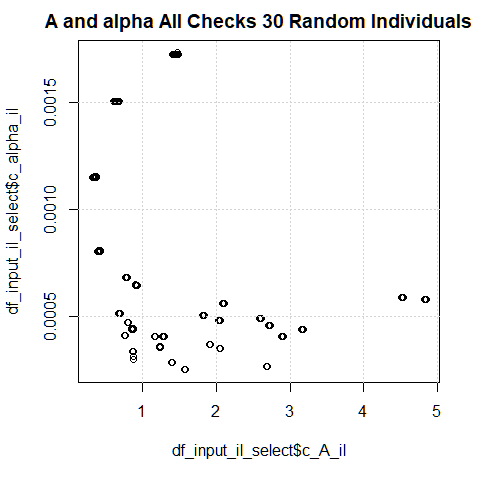

```r
grid()
```

#### Generate Alternative Allocations

Suppose we allocate Uniformly across individuals

```r
# checks - 1 because will have alpha + A, A = 11, alpha = adding 1 check given 11 checks
it_avg_check <- 12
# 2020 consumption
df_input_ib_select_c <- df_input_il_select %>%
  filter(D_il == it_avg_check-1) %>%
  rename(A_i_l0 = c_A_il) %>%
  rename(alpha_o_i = c_alpha_il) %>%
  select(id_i, A_i_l0, alpha_o_i, beta_i)
# value
df_input_ib_select_v <- df_input_il_select %>%
  filter(D_il == it_avg_check-1) %>%
  rename(A_i_l0 = v_A_il) %>%
  rename(alpha_o_i = v_alpha_il) %>%
  select(id_i, A_i_l0, alpha_o_i, beta_i)
# summarize
REconTools::ff_summ_percentiles(df_input_ib_select_c)
```

```
attributes are not identical across measure variables;
they will be dropped
```

| stats | A.i.l0 | alpha.o.i | beta.i | id.i |
| --- | --- | --- | --- | --- |
| n | 30 | 30 | 30 | 30 |
| unique | 30 | 30 | 1 | 30 |
| NAobs | 0 | 0 | 0 | 0 |
| ZEROobs | 0 | 0 | 0 | 0 |
| mean | 1.680743e+00 | 5.581518e-04 | 1.960784e-02 | 1.805867e+03 |
| sd | 1.124304e+00 | 3.370471e-04 | 0.000000e+00 | 9.629818e+02 |
| cv | 0.6689323 | 0.6038628 | 0.0000000 | 0.5332519 |
| min | 3.272889e-01 | 2.556713e-04 | 1.960784e-02 | 1.950000e+02 |
| p01 | 3.491409e-01 | 2.592544e-04 | 1.960784e-02 | 2.393700e+02 |
| p05 | 5.039937e-01 | 2.776118e-04 | 1.960784e-02 | 4.281000e+02 |

[output cut: 8 more lines]

```r
REconTools::ff_summ_percentiles(df_input_ib_select_v)
```

```
attributes are not identical across measure variables;
they will be dropped
```

| stats | A.i.l0 | alpha.o.i | beta.i | id.i |
| --- | --- | --- | --- | --- |
| n | 30 | 30 | 30 | 30 |
| unique | 30 | 30 | 1 | 30 |
| NAobs | 0 | 0 | 0 | 0 |
| ZEROobs | 0 | 0 | 0 | 0 |
| mean | 1.722849e+01 | 2.273861e-03 | 1.960784e-02 | 1.805867e+03 |
| sd | 2.324547e+00 | 3.237659e-03 | 0.000000e+00 | 9.629818e+02 |
| cv | 0.1349246 | 1.4238599 | 0.0000000 | 0.5332519 |
| min | 9.910038e+00 | 5.906598e-05 | 1.960784e-02 | 1.950000e+02 |
| p01 | 1.091749e+01 | 6.924996e-05 | 1.960784e-02 | 2.393700e+02 |
| p05 | 1.357115e+01 | 1.472504e-04 | 1.960784e-02 | 4.281000e+02 |

[output cut: 8 more lines]

#### Allocate for Random Subset

#### Allocation based on Consumption and Value

First Allocation based on 2020 Consumption:

```r
# Inputs
# 30 individuals 25 checks, half the amount is available
fl_dis_w <- it_draw*it_avg_check
df_input_il_c <- df_input_il_select %>%
  rename(A_il = c_A_il) %>%
  rename(alpha_il = c_alpha_il) %>%
  select(-v_A_il, -v_alpha_il)

# Solve with Function
ls_dis_solu_c <- suppressWarnings(suppressMessages(
  ffp_opt_anlyz_rhgin_dis(ar_rho,
                          fl_dis_w,
                          df_input_il_c,
                          bl_df_alloc_il = TRUE,
                          bl_return_V = TRUE,
                          bl_return_allQ_V = TRUE,
                          bl_return_inner_V = TRUE)))
```

```
|==========================================================================================================================|100% ~0 s remaining
```

```r
df_queue_il_long_c_test <-ls_dis_solu_c$df_queue_il_long
df_queue_il_wide_c_test <- ls_dis_solu_c$df_queue_il_wide
df_alloc_i_long_c_test <- ls_dis_solu_c$df_alloc_i_long
df_rho_gini_c_test <- ls_dis_solu_c$df_rho_gini
df_alloc_il_long_c_test <- ls_dis_solu_c$df_alloc_il_long
```

Second Allocation based on life-time utility:

```r
# Inputs
# 30 individuals 25 checks, half the amount is available
fl_dis_w <- it_draw*it_avg_check
df_input_il_v <- df_input_il_select %>%
  rename(A_il = v_A_il) %>%
  rename(alpha_il = v_alpha_il) %>%
  select(-c_A_il, -c_alpha_il)

# Solve with Function
ls_dis_solu_v <- suppressWarnings(suppressMessages(
  ffp_opt_anlyz_rhgin_dis(ar_rho,
                          fl_dis_w,
                          df_input_il_v,
                          bl_df_alloc_il = TRUE,
                          bl_return_V = TRUE,
                          bl_return_allQ_V = TRUE,
                          bl_return_inner_V = TRUE)))
```

```
|==========================================================================================================================|100% ~0 s remaining
```

```r
df_queue_il_long_v_test <-ls_dis_solu_v$df_queue_il_long
df_queue_il_wide_v_test <- ls_dis_solu_v$df_queue_il_wide
df_alloc_i_long_v_test <- ls_dis_solu_v$df_alloc_i_long
df_rho_gini_v_test <- ls_dis_solu_v$df_rho_gini
df_alloc_il_long_v_test <- ls_dis_solu_v$df_alloc_il_long
```

#### Allocate Results Review

Top of All 2020 c Frames:

```r
# Display Results
print(head(df_queue_il_long_c_test, 10))
```

| rho | rho_val | id_i | id_il | D_max_i | D_il | Q_il | D_Wbin_il | V_sum_l | V_inner_Q_il | V_star_Q_il |
| --- | --- | --- | --- | --- | --- | --- | --- | --- | --- | --- |
| 1 | 0.9900000 | 195 | 1 | 51 | 1 | 601 | 0 | 3.950432e-02 | 9.876124e-01 | 0.9874880 |
| 2 | 0.7845565 | 195 | 1 | 51 | 1 | 701 | 0 | 3.415972e-02 | 8.606691e-01 | 0.8259275 |
| 3 | -3.6415888 | 195 | 1 | 51 | 1 | 1007 | 0 | 1.490784e-03 | 1.582468e+00 | 0.8815796 |
| 4 | -99.0000000 | 195 | 1 | 51 | 1 | 1001 | 0 | 7.429416e-33 | 4.579336e+40 | 0.3884050 |
| 1 | 0.9900000 | 195 | 2 | 51 | 2 | 602 | 0 | 3.951362e-02 | 9.876217e-01 | 0.9874974 |
| 2 | 0.7845565 | 195 | 2 | 51 | 2 | 702 | 0 | 3.416610e-02 | 8.606755e-01 | 0.8259353 |
| 3 | -3.6415888 | 195 | 2 | 51 | 2 | 1010 | 0 | 1.489493e-03 | 1.582464e+00 | 0.8815802 |
| 4 | -99.0000000 | 195 | 2 | 51 | 2 | 1002 | 0 | 7.256560e-33 | 4.579336e+40 | 0.3884050 |
| 1 | 0.9900000 | 195 | 3 | 51 | 3 | 603 | 0 | 3.952292e-02 | 9.876310e-01 | 0.9875068 |
| 2 | 0.7845565 | 195 | 3 | 51 | 3 | 703 | 0 | 3.417247e-02 | 8.606819e-01 | 0.8259431 |

```r
# print(str(df_queue_il_long))
print(head(df_queue_il_wide_c_test, 10))
```

| id_il | A_il | alpha_il | beta_i | rank_min | rank_max | avg_rank | id_i | D_max_i | D_il | rho_c1_rk | rho_c2_rk | rho_c3_rk | rho_c4_rk |
| --- | --- | --- | --- | --- | --- | --- | --- | --- | --- | --- | --- | --- | --- |
| 1 | 2.028544 | 0.0004825434 | 0.01960784 | 1007 | 601 | 827.50 | 195 | 51 | 1 | 601 | 701 | 1007 | 1001 |
| 2 | 2.029026 | 0.0004825434 | 0.01960784 | 1010 | 602 | 829.00 | 195 | 51 | 2 | 602 | 702 | 1010 | 1002 |
| 3 | 2.029509 | 0.0004825434 | 0.01960784 | 1013 | 603 | 830.50 | 195 | 51 | 3 | 603 | 703 | 1013 | 1003 |
| 4 | 2.029991 | 0.0004825434 | 0.01960784 | 1016 | 604 | 832.00 | 195 | 51 | 4 | 604 | 704 | 1016 | 1004 |
| 5 | 2.030474 | 0.0004825434 | 0.01960784 | 1019 | 605 | 833.50 | 195 | 51 | 5 | 605 | 705 | 1019 | 1005 |
| 6 | 2.030956 | 0.0004825434 | 0.01960784 | 1022 | 606 | 835.00 | 195 | 51 | 6 | 606 | 706 | 1022 | 1006 |
| 7 | 2.031439 | 0.0004825434 | 0.01960784 | 1025 | 607 | 836.50 | 195 | 51 | 7 | 607 | 707 | 1025 | 1007 |
| 8 | 2.031921 | 0.0004825434 | 0.01960784 | 1028 | 608 | 838.00 | 195 | 51 | 8 | 608 | 708 | 1028 | 1008 |
| 9 | 2.032404 | 0.0004825434 | 0.01960784 | 1031 | 609 | 839.50 | 195 | 51 | 9 | 609 | 709 | 1031 | 1009 |
| 10 | 2.032886 | 0.0004825434 | 0.01960784 | 1035 | 610 | 841.25 | 195 | 51 | 10 | 610 | 710 | 1035 | 1010 |

```r
# print(str(df_queue_il_wide))
print(head(df_alloc_i_long_c_test, 10))
```

| rho | rho_val | id_i | D_max_i | D_star_i | F_star_i | EH_star_i |
| --- | --- | --- | --- | --- | --- | --- |
| 1 | 0.9900000 | 195 | 51 | 0 | 0 | 2.028544 |
| 2 | 0.7845565 | 195 | 51 | 0 | 0 | 2.028544 |
| 3 | -3.6415888 | 195 | 51 | 0 | 0 | 2.028544 |
| 4 | -99.0000000 | 195 | 51 | 0 | 0 | 2.028544 |
| 1 | 0.9900000 | 348 | 51 | 0 | 0 | 1.574174 |
| 2 | 0.7845565 | 348 | 51 | 0 | 0 | 1.574174 |
| 3 | -3.6415888 | 348 | 51 | 0 | 0 | 1.574174 |
| 4 | -99.0000000 | 348 | 51 | 0 | 0 | 1.574174 |
| 1 | 0.9900000 | 526 | 51 | 0 | 0 | 0.865558 |
| 2 | 0.7845565 | 526 | 51 | 0 | 0 | 0.865558 |

```r
# print(str(df_queue_il_wide))
print(df_rho_gini_c_test)
```

| rho | rho_val | gini_D_star | gini_EH_star | atkinson_EH_star | sd_D_star | sd_EH_star | mean_EH_star | min_EH_star |
| --- | --- | --- | --- | --- | --- | --- | --- | --- |
| 1 | 0.9900000 | 0.734767 | 0.3331966 | 0.001909448 | 21.39932 | 1.119525 | 1.687194 | 0.3732816 |
| 2 | 0.7845565 | 0.734767 | 0.3321545 | 0.001909448 | 21.39932 | 1.115446 | 1.687035 | 0.3732816 |
| 3 | -3.6415888 | 0.734767 | 0.3321278 | 0.001909448 | 21.39932 | 1.115605 | 1.684620 | 0.3732816 |
| 4 | -99.0000000 | 0.734767 | 0.3321355 | 0.001909448 | 21.39932 | 1.115647 | 1.684552 | 0.3732816 |
| 5 | 0.9900000 | 0.734767 | 0.3331966 | 0.001909448 | 21.39932 | 1.119525 | 1.687194 | 0.3732816 |
| 6 | 0.7845565 | 0.734767 | 0.3321545 | 0.001909448 | 21.39932 | 1.115446 | 1.687035 | 0.3732816 |
| 7 | -3.6415888 | 0.734767 | 0.3321278 | 0.001909448 | 21.39932 | 1.115605 | 1.684620 | 0.3732816 |
| 8 | -99.0000000 | 0.734767 | 0.3321355 | 0.001909448 | 21.39932 | 1.115647 | 1.684552 | 0.3732816 |
| 9 | 0.9900000 | 0.734767 | 0.3331966 | 0.001909448 | 21.39932 | 1.119525 | 1.687194 | 0.3732816 |
| 10 | 0.7845565 | 0.734767 | 0.3321545 | 0.001909448 | 21.39932 | 1.115446 | 1.687035 | 0.3732816 |

[output cut: 110 more lines]

```r
# print(str(df_alloc_i_long))
print(head(df_alloc_il_long_c_test, 10))
```

| rho | Q_il | sid_195 | sid_348 | sid_526 | sid_665 | sid_953 | sid_1011 | sid_1017 | sid_1038 | sid_1115 | sid_1142 | sid_1253 | sid_1268 | sid_1379 | sid_1450 | sid_1627 | sid_1673 | sid_1842 | sid_2013 | sid_2074 | sid_2227 | sid_2463 | sid_2511 | sid_2567 | sid_2650 | sid_2757 | sid_2888 | sid_2986 | sid_3371 | … |
| --- | --- | --- | --- | --- | --- | --- | --- | --- | --- | --- | --- | --- | --- | --- | --- | --- | --- | --- | --- | --- | --- | --- | --- | --- | --- | --- | --- | --- | --- | --- |
| 1 | 1 | 0 | 0 | 0 | 0 | 0 | 0 | 0 | 0 | 0 | 0 | 0 | 0 | 0 | 0 | 0 | 0 | 0 | 0 | 0 | 0 | 0 | 0 | 0 | 0 | 0 | 0 | 0 | 0 | … |
| 1 | 2 | 0 | 0 | 0 | 0 | 0 | 0 | 0 | 0 | 0 | 0 | 0 | 0 | 0 | 0 | 0 | 0 | 0 | 0 | 0 | 0 | 0 | 0 | 0 | 0 | 0 | 0 | 0 | 0 | … |
| 1 | 3 | 0 | 0 | 0 | 0 | 0 | 0 | 0 | 0 | 0 | 0 | 0 | 0 | 0 | 0 | 0 | 0 | 0 | 0 | 0 | 0 | 0 | 0 | 0 | 0 | 0 | 0 | 0 | 0 | … |
| 1 | 4 | 0 | 0 | 0 | 0 | 0 | 0 | 0 | 0 | 0 | 0 | 0 | 0 | 0 | 0 | 0 | 0 | 0 | 0 | 0 | 0 | 0 | 0 | 0 | 0 | 0 | 0 | 0 | 0 | … |
| 1 | 5 | 0 | 0 | 0 | 0 | 0 | 0 | 0 | 0 | 0 | 0 | 0 | 0 | 0 | 0 | 0 | 0 | 0 | 0 | 0 | 0 | 0 | 0 | 0 | 0 | 0 | 0 | 0 | 0 | … |
| 1 | 6 | 0 | 0 | 0 | 0 | 0 | 0 | 0 | 0 | 0 | 0 | 0 | 0 | 0 | 0 | 0 | 0 | 0 | 0 | 0 | 0 | 0 | 0 | 0 | 0 | 0 | 0 | 0 | 0 | … |
| 1 | 7 | 0 | 0 | 0 | 0 | 0 | 0 | 0 | 0 | 0 | 0 | 0 | 0 | 0 | 0 | 0 | 0 | 0 | 0 | 0 | 0 | 0 | 0 | 0 | 0 | 0 | 0 | 0 | 0 | … |
| 1 | 8 | 0 | 0 | 0 | 0 | 0 | 0 | 0 | 0 | 0 | 0 | 0 | 0 | 0 | 0 | 0 | 0 | 0 | 0 | 0 | 0 | 0 | 0 | 0 | 0 | 0 | 0 | 0 | 0 | … |
| 1 | 9 | 0 | 0 | 0 | 0 | 0 | 0 | 0 | 0 | 0 | 0 | 0 | 0 | 0 | 0 | 0 | 0 | 0 | 0 | 0 | 0 | 0 | 0 | 0 | 0 | 0 | 0 | 0 | 0 | … |
| 1 | 10 | 0 | 0 | 0 | 0 | 0 | 0 | 0 | 0 | 0 | 0 | 0 | 0 | 0 | 0 | 0 | 0 | 0 | 0 | 0 | 0 | 0 | 0 | 0 | 0 | 0 | 0 | 0 | 0 | … |

Top of All lifetime v Frames:

```r
# Display Results
print(head(df_queue_il_long_v_test, 10))
```

| rho | rho_val | id_i | id_il | D_max_i | D_il | Q_il | D_Wbin_il | V_sum_l | V_inner_Q_il | V_star_Q_il |
| --- | --- | --- | --- | --- | --- | --- | --- | --- | --- | --- |
| 1 | 0.9900000 | 195 | 1 | 51 | 1 | 1002 | 0 | 3.714747e-01 | 9.893071e+00 | 10.124766 |
| 2 | 0.7845565 | 195 | 1 | 51 | 1 | 1001 | 0 | 2.017550e-01 | 5.501687e+00 | 8.786989 |
| 3 | -3.6415888 | 195 | 1 | 51 | 1 | 1051 | 0 | 3.920226e-07 | 2.223578e-05 | 18.955035 |
| 4 | -99.0000000 | 195 | 1 | 51 | 1 | 1226 | 0 | 3.487315e-130 | 2.134605e-103 | 10.891247 |
| 1 | 0.9900000 | 195 | 2 | 51 | 2 | 1003 | 0 | 3.714864e-01 | 9.893083e+00 | 10.124778 |
| 2 | 0.7845565 | 195 | 2 | 51 | 2 | 1002 | 0 | 2.017600e-01 | 5.501692e+00 | 8.787000 |
| 3 | -3.6415888 | 195 | 2 | 51 | 2 | 1052 | 0 | 3.919771e-07 | 2.223574e-05 | 18.955045 |
| 4 | -99.0000000 | 195 | 2 | 51 | 2 | 1229 | 0 | 3.476331e-130 | 2.134605e-103 | 10.891247 |
| 1 | 0.9900000 | 195 | 3 | 51 | 3 | 1004 | 0 | 3.714981e-01 | 9.893095e+00 | 10.124790 |
| 2 | 0.7845565 | 195 | 3 | 51 | 3 | 1003 | 0 | 2.017651e-01 | 5.501697e+00 | 8.787010 |

```r
# print(str(df_queue_il_long))
print(head(df_queue_il_wide_v_test, 10))
```

| id_il | A_il | alpha_il | beta_i | rank_min | rank_max | avg_rank | id_i | D_max_i | D_il | rho_c1_rk | rho_c2_rk | rho_c3_rk | rho_c4_rk |
| --- | --- | --- | --- | --- | --- | --- | --- | --- | --- | --- | --- | --- | --- |
| 1 | 19.51594 | 0.000621938 | 0.01960784 | 1226 | 1001 | 1070.00 | 195 | 51 | 1 | 1002 | 1001 | 1051 | 1226 |
| 2 | 19.51657 | 0.000621938 | 0.01960784 | 1229 | 1002 | 1071.50 | 195 | 51 | 2 | 1003 | 1002 | 1052 | 1229 |
| 3 | 19.51719 | 0.000621938 | 0.01960784 | 1231 | 1003 | 1072.75 | 195 | 51 | 3 | 1004 | 1003 | 1053 | 1231 |
| 4 | 19.51781 | 0.000621938 | 0.01960784 | 1234 | 1004 | 1074.25 | 195 | 51 | 4 | 1005 | 1004 | 1054 | 1234 |
| 5 | 19.51843 | 0.000621938 | 0.01960784 | 1236 | 1005 | 1075.50 | 195 | 51 | 5 | 1006 | 1005 | 1055 | 1236 |
| 6 | 19.51905 | 0.000621938 | 0.01960784 | 1239 | 1006 | 1077.00 | 195 | 51 | 6 | 1007 | 1006 | 1056 | 1239 |
| 7 | 19.51968 | 0.000621938 | 0.01960784 | 1241 | 1007 | 1078.25 | 195 | 51 | 7 | 1008 | 1007 | 1057 | 1241 |
| 8 | 19.52030 | 0.000621938 | 0.01960784 | 1244 | 1008 | 1079.75 | 195 | 51 | 8 | 1009 | 1008 | 1058 | 1244 |
| 9 | 19.52092 | 0.000621938 | 0.01960784 | 1247 | 1009 | 1081.25 | 195 | 51 | 9 | 1010 | 1009 | 1059 | 1247 |
| 10 | 19.52154 | 0.000621938 | 0.01960784 | 1249 | 1010 | 1082.50 | 195 | 51 | 10 | 1011 | 1010 | 1060 | 1249 |

```r
# print(str(df_queue_il_wide))
print(head(df_alloc_i_long_v_test, 10))
```

| rho | rho_val | id_i | D_max_i | D_star_i | F_star_i | EH_star_i |
| --- | --- | --- | --- | --- | --- | --- |
| 1 | 0.9900000 | 195 | 51 | 0 | 0.0000000 | 19.51594 |
| 2 | 0.7845565 | 195 | 51 | 0 | 0.0000000 | 19.51594 |
| 3 | -3.6415888 | 195 | 51 | 0 | 0.0000000 | 19.51594 |
| 4 | -99.0000000 | 195 | 51 | 0 | 0.0000000 | 19.51594 |
| 1 | 0.9900000 | 348 | 51 | 0 | 0.0000000 | 17.59922 |
| 2 | 0.7845565 | 348 | 51 | 0 | 0.0000000 | 17.59922 |
| 3 | -3.6415888 | 348 | 51 | 0 | 0.0000000 | 17.59922 |
| 4 | -99.0000000 | 348 | 51 | 0 | 0.0000000 | 17.59922 |
| 1 | 0.9900000 | 526 | 51 | 50 | 0.9803922 | 13.54355 |
| 2 | 0.7845565 | 526 | 51 | 50 | 0.9803922 | 13.54355 |

```r
# print(str(df_queue_il_wide))
print(df_rho_gini_v_test)
```

| rho | rho_val | gini_D_star | gini_EH_star | atkinson_EH_star | sd_D_star | sd_EH_star | mean_EH_star | min_EH_star |
| --- | --- | --- | --- | --- | --- | --- | --- | --- |
| 1 | 0.9900000 | 0.734767 | 0.06643304 | 8.373252e-05 | 21.39932 | 2.213711 | 17.28253 | 10.46717 |
| 2 | 0.7845565 | 0.734767 | 0.06643304 | 8.373252e-05 | 21.39932 | 2.213711 | 17.28253 | 10.46717 |
| 3 | -3.6415888 | 0.734767 | 0.06643304 | 8.373252e-05 | 21.39932 | 2.213711 | 17.28253 | 10.46717 |
| 4 | -99.0000000 | 0.734767 | 0.06643304 | 8.373252e-05 | 21.39932 | 2.213711 | 17.28253 | 10.46717 |
| 5 | 0.9900000 | 0.734767 | 0.06643304 | 8.373252e-05 | 21.39932 | 2.213711 | 17.28253 | 10.46717 |
| 6 | 0.7845565 | 0.734767 | 0.06643304 | 8.373252e-05 | 21.39932 | 2.213711 | 17.28253 | 10.46717 |
| 7 | -3.6415888 | 0.734767 | 0.06643304 | 8.373252e-05 | 21.39932 | 2.213711 | 17.28253 | 10.46717 |
| 8 | -99.0000000 | 0.734767 | 0.06643304 | 8.373252e-05 | 21.39932 | 2.213711 | 17.28253 | 10.46717 |
| 9 | 0.9900000 | 0.734767 | 0.06643304 | 8.373252e-05 | 21.39932 | 2.213711 | 17.28253 | 10.46717 |
| 10 | 0.7845565 | 0.734767 | 0.06643304 | 8.373252e-05 | 21.39932 | 2.213711 | 17.28253 | 10.46717 |

[output cut: 110 more lines]

```r
# print(str(df_alloc_i_long))
print(head(df_alloc_il_long_v_test, 10))
```

| rho | Q_il | sid_195 | sid_348 | sid_526 | sid_665 | sid_953 | sid_1011 | sid_1017 | sid_1038 | sid_1115 | sid_1142 | sid_1253 | sid_1268 | sid_1379 | sid_1450 | sid_1627 | sid_1673 | sid_1842 | sid_2013 | sid_2074 | sid_2227 | sid_2463 | sid_2511 | sid_2567 | sid_2650 | sid_2757 | sid_2888 | sid_2986 | sid_3371 | … |
| --- | --- | --- | --- | --- | --- | --- | --- | --- | --- | --- | --- | --- | --- | --- | --- | --- | --- | --- | --- | --- | --- | --- | --- | --- | --- | --- | --- | --- | --- | --- |
| 1 | 1 | 0 | 0 | 0 | 0 | 0 | 0 | 0 | 0 | 0 | 0 | 0 | 0 | 0 | 0 | 0 | 0 | 0 | 0 | 0 | 0 | 0 | 0 | 0 | 0 | 0 | 0 | 1 | 0 | … |
| 1 | 2 | 0 | 0 | 0 | 0 | 0 | 0 | 0 | 0 | 0 | 0 | 0 | 0 | 0 | 0 | 0 | 0 | 0 | 0 | 0 | 0 | 0 | 0 | 0 | 0 | 0 | 0 | 2 | 0 | … |
| 1 | 3 | 0 | 0 | 0 | 0 | 0 | 0 | 0 | 0 | 0 | 0 | 0 | 0 | 0 | 0 | 0 | 0 | 0 | 0 | 0 | 0 | 0 | 0 | 0 | 0 | 0 | 0 | 3 | 0 | … |
| 1 | 4 | 0 | 0 | 0 | 0 | 0 | 0 | 0 | 0 | 0 | 0 | 0 | 0 | 0 | 0 | 0 | 0 | 0 | 0 | 0 | 0 | 0 | 0 | 0 | 0 | 0 | 0 | 4 | 0 | … |
| 1 | 5 | 0 | 0 | 0 | 0 | 0 | 0 | 0 | 0 | 0 | 0 | 0 | 0 | 0 | 0 | 0 | 0 | 0 | 0 | 0 | 0 | 0 | 0 | 0 | 0 | 0 | 0 | 5 | 0 | … |
| 1 | 6 | 0 | 0 | 0 | 0 | 0 | 0 | 0 | 0 | 0 | 0 | 0 | 0 | 0 | 0 | 0 | 0 | 0 | 0 | 0 | 0 | 0 | 0 | 0 | 0 | 0 | 0 | 6 | 0 | … |
| 1 | 7 | 0 | 0 | 0 | 0 | 0 | 0 | 0 | 0 | 0 | 0 | 0 | 0 | 0 | 0 | 0 | 0 | 0 | 0 | 0 | 0 | 0 | 0 | 0 | 0 | 0 | 0 | 7 | 0 | … |
| 1 | 8 | 0 | 0 | 0 | 0 | 0 | 0 | 0 | 0 | 0 | 0 | 0 | 0 | 0 | 0 | 0 | 0 | 0 | 0 | 0 | 0 | 0 | 0 | 0 | 0 | 0 | 0 | 8 | 0 | … |
| 1 | 9 | 0 | 0 | 0 | 0 | 0 | 0 | 0 | 0 | 0 | 0 | 0 | 0 | 0 | 0 | 0 | 0 | 0 | 0 | 0 | 0 | 0 | 0 | 0 | 0 | 0 | 0 | 9 | 0 | … |
| 1 | 10 | 0 | 0 | 0 | 0 | 0 | 0 | 0 | 0 | 0 | 0 | 0 | 0 | 0 | 0 | 0 | 0 | 0 | 0 | 0 | 0 | 0 | 0 | 0 | 0 | 0 | 0 | 10 | 0 | … |

##### Review df_queue_il_long_test

Review the long frame allocation queue for all preference levels and individuals.

```r
# Summarize
REconTools::ff_summ_percentiles(df_queue_il_long_c_test)
```

```
attributes are not identical across measure variables;
they will be dropped
```

| stats | D.il | D.max.i | D.Wbin.il | id.i | id.il | Q.il | rho | rho.val | V.inner.Q.il | V.star.Q.il | V.sum.l |
| --- | --- | --- | --- | --- | --- | --- | --- | --- | --- | --- | --- |
| n | 6000 | 6000 | 6000 | 6000 | 6000 | 6000 | 6000 | 6000 | 6000 | 6000 | 6000 |
| unique | 50 | 1 | 2 | 30 | 1500 | 1500 | 4 | 4 | 4600 | 4600 | 6000 |
| NAobs | 0 | 0 | 0 | 0 | 0 | 0 | 0 | 0 | 0 | 0 | 0 |
| ZEROobs | 0 | 0 | 4560 | 0 | 0 | 0 | 0 | 0 | 0 | 0 | 0 |
| mean | 2.550000e+01 | 5.100000e+01 | 2.400000e-01 | 1.805867e+03 | 7.505000e+02 | 7.505000e+02 | 2.500000e+00 | -2.521676e+01 | 2.761633e+44 | 7.697517e-01 | 2.761522e+44 |
| sd | 1.443207e+01 | 0.000000e+00 | 4.271187e-01 | 9.468750e+02 | 4.330487e+02 | 4.330487e+02 | 1.118127e+00 | 4.264249e+01 | 8.950707e+45 | 2.285520e-01 | 8.950707e+45 |
| cv | 0.5659636 | 0.0000000 | 1.7796614 | 0.5243327 | 0.5770136 | 0.5770136 | 0.4472509 | -1.6910380 | 32.4109226 | 0.2969165 | 32.4122228 |
| min | 1.000000e+00 | 5.100000e+01 | 0.000000e+00 | 1.950000e+02 | 1.000000e+00 | 1.000000e+00 | 1.000000e+00 | -9.900000e+01 | 8.524143e-01 | 3.297855e-01 | 2.652352e-70 |
| p01 | 1.000000e+00 | 5.100000e+01 | 0.000000e+00 | 1.950000e+02 | 1.599000e+01 | 1.599000e+01 | 1.000000e+00 | -9.900000e+01 | 8.539283e-01 | 3.884032e-01 | 1.805727e-67 |
| p05 | 3.000000e+00 | 5.100000e+01 | 0.000000e+00 | 3.480000e+02 | 7.595000e+01 | 7.595000e+01 | 1.000000e+00 | -9.900000e+01 | 8.577780e-01 | 3.884050e-01 | 8.169015e-44 |

[output cut: 8 more lines]

```r
# list
df_queue_il_long_c_test %>%
  arrange(rho_val, Q_il) %>%
  select(rho_val, id_i, id_il, Q_il, D_Wbin_il, V_sum_l, V_inner_Q_il, V_star_Q_il)
```

| rho_val | id_i | id_il | Q_il | D_Wbin_il | V_sum_l | V_inner_Q_il | V_star_Q_il |
| --- | --- | --- | --- | --- | --- | --- | --- |
| -99 | 3371 | 1351 | 1 | 1 | 4.955362e+47 | 4.955362e+47 | 0.3297855 |
| -99 | 3371 | 1352 | 2 | 1 | 3.462901e+47 | 3.462901e+47 | 0.3309814 |
| -99 | 3371 | 1353 | 3 | 1 | 2.423071e+47 | 2.423071e+47 | 0.3321774 |
| -99 | 3371 | 1354 | 4 | 1 | 1.697656e+47 | 1.697656e+47 | 0.3333733 |
| -99 | 3371 | 1355 | 5 | 1 | 1.190930e+47 | 1.190930e+47 | 0.3345692 |
| -99 | 3371 | 1356 | 6 | 1 | 8.365123e+46 | 8.365123e+46 | 0.3357652 |
| -99 | 3371 | 1357 | 7 | 1 | 5.883068e+46 | 5.883068e+46 | 0.3369611 |
| -99 | 3371 | 1358 | 8 | 1 | 4.142638e+46 | 4.142638e+46 | 0.3381570 |
| -99 | 3371 | 1359 | 9 | 1 | 2.920706e+46 | 2.920706e+46 | 0.3393530 |
| -99 | 3371 | 1360 | 10 | 1 | 2.061735e+46 | 2.061735e+46 | 0.3405489 |

[output cut: 990 more lines]

##### Review Individual Allocation Levels at Resources

```r
# Summarize
svr_group_var = 'rho_val'
df = df_alloc_i_long_c_test
it_group_vals = 3
col2varname = FALSE
bl_kable = TRUE

# Unique Variable
ar_group_uniques <- sort(unique(df %>% pull(!!sym(svr_group_var))))
if (missing(it_group_vals)) {
  it_group_vals <- length(ar_group_uniques)
}
ar_group_select <- ar_group_uniques[unique(seq(1, length(ar_group_uniques),
                            length.out = it_group_vals))]

# Unique Values of the Group
ls_summ_all_vars_by_group = suppressWarnings(
  lapply(ar_group_select, function(row) {
          # group value
          fl_group_val = row[1]

          # summarize
          tb_summ_stats <- REconTools::ff_summ_percentiles(
            df %>% filter(!!sym(svr_group_var) == fl_group_val),
            bl_statsasrows = FALSE,
            col2varname = col2varname)

          # Add Group Var as Column
          tb_summ_stats <- tb_summ_stats %>%
            mutate(!!sym(svr_group_var) := fl_group_val) %>%
            select(!!sym(svr_group_var), everything())

          return(tb_summ_stats)
        }))

# Stack Summ Stats Each Group Together:
mt_summ_all_vars_by_group <- do.call(rbind, ls_summ_all_vars_by_group)

# sort
mt_summ_all_vars_by_group <- mt_summ_all_vars_by_group %>%
  arrange(var, !!sym(svr_group_var))

# Print
print(mt_summ_all_vars_by_group)
```

| rho_val | var | n | unique | NAobs | ZEROobs | mean | sd | cv | min | p01 | p05 | p10 | p25 | p50 | p75 | p90 | p95 | p99 | max |
| --- | --- | --- | --- | --- | --- | --- | --- | --- | --- | --- | --- | --- | --- | --- | --- | --- | --- | --- | --- |
| -99.000000 | D.max.i | 30 | 1 | 0 | 0 | 51.0000000 | 0.0000000 | 0.0000000 | 51.0000000 | 51.0000000 | 51.0000000 | 51.0000000 | 51.0000000 | 51.000000 | 51.0000000 | 51.0000000 | 51.0000000 | 51.0000000 | 51.0000000 |
| -3.641589 | D.max.i | 30 | 1 | 0 | 0 | 51.0000000 | 0.0000000 | 0.0000000 | 51.0000000 | 51.0000000 | 51.0000000 | 51.0000000 | 51.0000000 | 51.000000 | 51.0000000 | 51.0000000 | 51.0000000 | 51.0000000 | 51.0000000 |
| 0.990000 | D.max.i | 30 | 1 | 0 | 0 | 51.0000000 | 0.0000000 | 0.0000000 | 51.0000000 | 51.0000000 | 51.0000000 | 51.0000000 | 51.0000000 | 51.000000 | 51.0000000 | 51.0000000 | 51.0000000 | 51.0000000 | 51.0000000 |
| -99.000000 | D.star.i | 30 | 3 | 0 | 22 | 12.0000000 | 21.3993232 | 1.7832769 | 0.0000000 | 0.0000000 | 0.0000000 | 0.0000000 | 0.0000000 | 0.000000 | 7.5000000 | 50.0000000 | 50.0000000 | 50.0000000 | 50.0000000 |
| -3.641589 | D.star.i | 30 | 3 | 0 | 22 | 12.0000000 | 21.3993232 | 1.7832769 | 0.0000000 | 0.0000000 | 0.0000000 | 0.0000000 | 0.0000000 | 0.000000 | 7.5000000 | 50.0000000 | 50.0000000 | 50.0000000 | 50.0000000 |
| 0.990000 | D.star.i | 30 | 3 | 0 | 22 | 12.0000000 | 21.3993232 | 1.7832769 | 0.0000000 | 0.0000000 | 0.0000000 | 0.0000000 | 0.0000000 | 0.000000 | 7.5000000 | 50.0000000 | 50.0000000 | 50.0000000 | 50.0000000 |
| -99.000000 | EH.star.i | 30 | 30 | 0 | 0 | 1.6845524 | 1.1156468 | 0.6622809 | 0.3732816 | 0.3911588 | 0.5488253 | 0.6947534 | 0.8540894 | 1.335095 | 2.0727671 | 2.9125400 | 3.9025561 | 4.7307152 | 4.8188075 |
| -3.641589 | EH.star.i | 30 | 30 | 0 | 0 | 1.6846196 | 1.1156048 | 0.6622295 | 0.3732816 | 0.3911588 | 0.5488253 | 0.6947534 | 0.8507362 | 1.335095 | 2.0727671 | 2.9125400 | 3.9025561 | 4.7307152 | 4.8188075 |
| 0.990000 | EH.star.i | 30 | 30 | 0 | 0 | 1.6871942 | 1.1195250 | 0.6635424 | 0.3732816 | 0.3911588 | 0.5405777 | 0.6862015 | 0.8507362 | 1.335095 | 2.0727671 | 2.9125400 | 3.9187858 | 4.7433876 | 4.8246032 |
| -99.000000 | F.star.i | 30 | 3 | 0 | 22 | 0.2352941 | 0.4195946 | 1.7832769 | 0.0000000 | 0.0000000 | 0.0000000 | 0.0000000 | 0.0000000 | 0.000000 | 0.1470588 | 0.9803922 | 0.9803922 | 0.9803922 | 0.9803922 |

[output cut: 11 more lines]

##### Allocation Amounts by Attributes

Join the allocation level dataframe with individual attributes:

```r
# Summarize
df_alloc_i_long_test_c_covar <- df_alloc_i_long_c_test %>%
  left_join(df_id, by = "id_i")
df_alloc_i_long_test_v_covar <- df_alloc_i_long_v_test %>%
  left_join(df_id, by = "id_i")
```

Summarize check level statistics by key attributes:

```r
ls_svr_groups <- c('ymin', 'marital', 'kids', 'age')
for (svr_group in ls_svr_groups) {

  # Group by variable
  print(paste0('current group = ', svr_group))

  # Summarize C
  df <- df_alloc_i_long_test_c_covar
  vars.group <- c('rho_val', svr_group)
  var.numeric <- 'D_star_i'
  str.stats.group <- 'allperc'
  ar.perc <- c(0.10, 0.5, 0.90)
  ls_summ_by_group <- REconTools::ff_summ_bygroup(
    df, vars.group, var.numeric, str.stats.group, ar.perc)
  print(ls_summ_by_group$df_table_grp_stats)

  # Summarize V
  df <- df_alloc_i_long_test_v_covar
  vars.group <- c('rho_val', svr_group)
  var.numeric <- 'D_star_i'
  str.stats.group <- 'allperc'
  ar.perc <- c(0.10, 0.5, 0.90)
  ls_summ_by_group <- REconTools::ff_summ_bygroup(
    df, vars.group, var.numeric, str.stats.group, ar.perc)
  print(ls_summ_by_group$df_table_grp_stats)

}
```

```
[1] "current group = ymin"
```

```
attributes are not identical across measure variables;
they will be dropped
```

| rho.val | ymin | mean | median | sd | IQR | mad | 10% | 50% | 90% | min | max | first | last | n.distinct |
| --- | --- | --- | --- | --- | --- | --- | --- | --- | --- | --- | --- | --- | --- | --- |
| -99.0000000 | 38607.24 | 50.00000 | 50 | 0.00000 | 0 | 0.000 | 50 | 50 | 50 | 50 | 50 | 50 | 50 | 1 |
| -99.0000000 | 40639.20 | 50.00000 | 50 | NA | 0 | 0.000 | 50 | 50 | 50 | 50 | 50 | 50 | 50 | 1 |
| -99.0000000 | 65022.72 | 10.00000 | 10 | NA | 0 | 0.000 | 10 | 10 | 10 | 10 | 10 | 10 | 10 | 1 |
| -99.0000000 | 73150.56 | 0.00000 | 0 | NA | 0 | 0.000 | 0 | 0 | 0 | 0 | 0 | 0 | 0 | 1 |
| -99.0000000 | 75182.52 | 0.00000 | 0 | NA | 0 | 0.000 | 0 | 0 | 0 | 0 | 0 | 0 | 0 | 1 |
| -99.0000000 | 85342.32 | 33.33333 | 50 | 28.86751 | 25 | 0.000 | 10 | 50 | 50 | 0 | 50 | 0 | 50 | 2 |
| -99.0000000 | 87374.28 | 0.00000 | 0 | 0.00000 | 0 | 0.000 | 0 | 0 | 0 | 0 | 0 | 0 | 0 | 1 |
| -99.0000000 | 89406.24 | 50.00000 | 50 | NA | 0 | 0.000 | 50 | 50 | 50 | 50 | 50 | 50 | 50 | 1 |
| -99.0000000 | 101598.00 | 0.00000 | 0 | NA | 0 | 0.000 | 0 | 0 | 0 | 0 | 0 | 0 | 0 | 1 |
| -99.0000000 | 105661.92 | 0.00000 | 0 | NA | 0 | 0.000 | 0 | 0 | 0 | 0 | 0 | 0 | 0 | 1 |

[output cut: 90 more lines]

```
attributes are not identical across measure variables;
they will be dropped
```

| rho.val | ymin | mean | median | sd | IQR | mad | 10% | 50% | 90% | min | max | first | last | n.distinct |
| --- | --- | --- | --- | --- | --- | --- | --- | --- | --- | --- | --- | --- | --- | --- |
| -99.0000000 | 38607.24 | 50.00000 | 50 | 0.00000 | 0 | 0 | 50 | 50 | 50 | 50 | 50 | 50 | 50 | 1 |
| -99.0000000 | 40639.20 | 50.00000 | 50 | NA | 0 | 0 | 50 | 50 | 50 | 50 | 50 | 50 | 50 | 1 |
| -99.0000000 | 65022.72 | 50.00000 | 50 | NA | 0 | 0 | 50 | 50 | 50 | 50 | 50 | 50 | 50 | 1 |
| -99.0000000 | 73150.56 | 0.00000 | 0 | NA | 0 | 0 | 0 | 0 | 0 | 0 | 0 | 0 | 0 | 1 |
| -99.0000000 | 75182.52 | 50.00000 | 50 | NA | 0 | 0 | 50 | 50 | 50 | 50 | 50 | 50 | 50 | 1 |
| -99.0000000 | 85342.32 | 36.66667 | 50 | 23.09401 | 20 | 0 | 18 | 50 | 50 | 10 | 50 | 10 | 50 | 2 |
| -99.0000000 | 87374.28 | 0.00000 | 0 | 0.00000 | 0 | 0 | 0 | 0 | 0 | 0 | 0 | 0 | 0 | 1 |
| -99.0000000 | 89406.24 | 0.00000 | 0 | NA | 0 | 0 | 0 | 0 | 0 | 0 | 0 | 0 | 0 | 1 |
| -99.0000000 | 101598.00 | 0.00000 | 0 | NA | 0 | 0 | 0 | 0 | 0 | 0 | 0 | 0 | 0 | 1 |
| -99.0000000 | 105661.92 | 0.00000 | 0 | NA | 0 | 0 | 0 | 0 | 0 | 0 | 0 | 0 | 0 | 1 |

[output cut: 90 more lines]

```
[1] "current group = marital"
```

```
attributes are not identical across measure variables;
they will be dropped
```

| rho.val | marital | mean | median | sd | IQR | mad | 10% | 50% | 90% | min | max | first | last | n.distinct |
| --- | --- | --- | --- | --- | --- | --- | --- | --- | --- | --- | --- | --- | --- | --- |
| -99.0000000 | 0 | 15.789474 | 0 | 23.87835 | 50 | 0 | 0 | 0 | 50 | 0 | 50 | 0 | 50 | 2 |
| -99.0000000 | 1 | 5.454545 | 0 | 15.07557 | 0 | 0 | 0 | 0 | 10 | 0 | 50 | 0 | 50 | 3 |
| -3.6415888 | 0 | 16.315789 | 0 | 23.61980 | 50 | 0 | 0 | 0 | 50 | 0 | 50 | 0 | 50 | 3 |
| -3.6415888 | 1 | 4.545455 | 0 | 15.07557 | 0 | 0 | 0 | 0 | 0 | 0 | 50 | 0 | 50 | 2 |
| 0.7845565 | 0 | 13.684211 | 0 | 22.41292 | 30 | 0 | 0 | 0 | 50 | 0 | 50 | 0 | 50 | 3 |
| 0.7845565 | 1 | 9.090909 | 0 | 20.22600 | 0 | 0 | 0 | 0 | 50 | 0 | 50 | 0 | 50 | 2 |
| 0.9900000 | 0 | 13.684211 | 0 | 22.41292 | 30 | 0 | 0 | 0 | 50 | 0 | 50 | 0 | 50 | 3 |
| 0.9900000 | 1 | 9.090909 | 0 | 20.22600 | 0 | 0 | 0 | 0 | 50 | 0 | 50 | 0 | 50 | 2 |

```
attributes are not identical across measure variables;
they will be dropped
```

| rho.val | marital | mean | median | sd | IQR | mad | 10% | 50% | 90% | min | max | first | last | n.distinct |
| --- | --- | --- | --- | --- | --- | --- | --- | --- | --- | --- | --- | --- | --- | --- |
| -99.0000000 | 0 | 13.684211 | 0 | 22.41292 | 30 | 0 | 0 | 0 | 50 | 0 | 50 | 0 | 50 | 3 |
| -99.0000000 | 1 | 9.090909 | 0 | 20.22600 | 0 | 0 | 0 | 0 | 50 | 0 | 50 | 0 | 50 | 2 |
| -3.6415888 | 0 | 13.684211 | 0 | 22.41292 | 30 | 0 | 0 | 0 | 50 | 0 | 50 | 0 | 50 | 3 |
| -3.6415888 | 1 | 9.090909 | 0 | 20.22600 | 0 | 0 | 0 | 0 | 50 | 0 | 50 | 0 | 50 | 2 |
| 0.7845565 | 0 | 13.684211 | 0 | 22.41292 | 30 | 0 | 0 | 0 | 50 | 0 | 50 | 0 | 50 | 3 |
| 0.7845565 | 1 | 9.090909 | 0 | 20.22600 | 0 | 0 | 0 | 0 | 50 | 0 | 50 | 0 | 50 | 2 |
| 0.9900000 | 0 | 13.684211 | 0 | 22.41292 | 30 | 0 | 0 | 0 | 50 | 0 | 50 | 0 | 50 | 3 |
| 0.9900000 | 1 | 9.090909 | 0 | 20.22600 | 0 | 0 | 0 | 0 | 50 | 0 | 50 | 0 | 50 | 2 |

```
[1] "current group = kids"
```

```
attributes are not identical across measure variables;
they will be dropped
```

| rho.val | kids | mean | median | sd | IQR | mad | 10% | 50% | 90% | min | max | first | last | n.distinct |
| --- | --- | --- | --- | --- | --- | --- | --- | --- | --- | --- | --- | --- | --- | --- |
| -99.0000000 | 0 | 17.333333 | 0 | 24.04361 | 50.0 | 0 | 0 | 0 | 50 | 0 | 50 | 0 | 50 | 3 |
| -99.0000000 | 1 | 6.250000 | 0 | 17.67767 | 0.0 | 0 | 0 | 0 | 15 | 0 | 50 | 0 | 50 | 2 |
| -99.0000000 | 2 | 7.142857 | 0 | 18.89822 | 0.0 | 0 | 0 | 0 | 20 | 0 | 50 | 0 | 50 | 2 |
| -3.6415888 | 0 | 17.333333 | 0 | 24.04361 | 50.0 | 0 | 0 | 0 | 50 | 0 | 50 | 0 | 50 | 3 |
| -3.6415888 | 1 | 6.250000 | 0 | 17.67767 | 0.0 | 0 | 0 | 0 | 15 | 0 | 50 | 0 | 50 | 2 |
| -3.6415888 | 2 | 7.142857 | 0 | 18.89822 | 0.0 | 0 | 0 | 0 | 20 | 0 | 50 | 0 | 50 | 2 |
| 0.7845565 | 0 | 17.333333 | 0 | 24.04361 | 50.0 | 0 | 0 | 0 | 50 | 0 | 50 | 0 | 50 | 3 |
| 0.7845565 | 1 | 6.250000 | 0 | 17.67767 | 0.0 | 0 | 0 | 0 | 15 | 0 | 50 | 0 | 50 | 2 |
| 0.7845565 | 2 | 7.142857 | 0 | 18.89822 | 0.0 | 0 | 0 | 0 | 20 | 0 | 50 | 0 | 50 | 2 |
| 0.9900000 | 0 | 14.000000 | 0 | 22.61479 | 30.0 | 0 | 0 | 0 | 50 | 0 | 50 | 0 | 50 | 3 |

[output cut: 2 more lines]

```
attributes are not identical across measure variables;
they will be dropped
```

| rho.val | kids | mean | median | sd | IQR | mad | 10% | 50% | 90% | min | max | first | last | n.distinct |
| --- | --- | --- | --- | --- | --- | --- | --- | --- | --- | --- | --- | --- | --- | --- |
| -99.0000000 | 0 | 10.66667 | 0 | 20.51712 | 5.0 | 0 | 0 | 0 | 50 | 0 | 50 | 0 | 50 | 3 |
| -99.0000000 | 1 | 12.50000 | 0 | 23.14550 | 12.5 | 0 | 0 | 0 | 50 | 0 | 50 | 0 | 50 | 2 |
| -99.0000000 | 2 | 14.28571 | 0 | 24.39750 | 25.0 | 0 | 0 | 0 | 50 | 0 | 50 | 0 | 50 | 2 |
| -3.6415888 | 0 | 10.66667 | 0 | 20.51712 | 5.0 | 0 | 0 | 0 | 50 | 0 | 50 | 0 | 50 | 3 |
| -3.6415888 | 1 | 12.50000 | 0 | 23.14550 | 12.5 | 0 | 0 | 0 | 50 | 0 | 50 | 0 | 50 | 2 |
| -3.6415888 | 2 | 14.28571 | 0 | 24.39750 | 25.0 | 0 | 0 | 0 | 50 | 0 | 50 | 0 | 50 | 2 |
| 0.7845565 | 0 | 10.66667 | 0 | 20.51712 | 5.0 | 0 | 0 | 0 | 50 | 0 | 50 | 0 | 50 | 3 |
| 0.7845565 | 1 | 12.50000 | 0 | 23.14550 | 12.5 | 0 | 0 | 0 | 50 | 0 | 50 | 0 | 50 | 2 |
| 0.7845565 | 2 | 14.28571 | 0 | 24.39750 | 25.0 | 0 | 0 | 0 | 50 | 0 | 50 | 0 | 50 | 2 |
| 0.9900000 | 0 | 10.66667 | 0 | 20.51712 | 5.0 | 0 | 0 | 0 | 50 | 0 | 50 | 0 | 50 | 3 |

[output cut: 2 more lines]

```
[1] "current group = age"
```

```
attributes are not identical across measure variables;
they will be dropped
```

| rho.val | age | mean | median | sd | IQR | mad | 10% | 50% | 90% | min | max | first | last | n.distinct |
| --- | --- | --- | --- | --- | --- | --- | --- | --- | --- | --- | --- | --- | --- | --- |
| -99.0000000 | 20 | 0.000000 | 0 | NA | 0.0 | 0.000 | 0 | 0 | 0 | 0 | 0 | 0 | 0 | 1 |
| -99.0000000 | 21 | 0.000000 | 0 | NA | 0.0 | 0.000 | 0 | 0 | 0 | 0 | 0 | 0 | 0 | 1 |
| -99.0000000 | 22 | 0.000000 | 0 | 0.000000 | 0.0 | 0.000 | 0 | 0 | 0 | 0 | 0 | 0 | 0 | 1 |
| -99.0000000 | 24 | 7.142857 | 0 | 18.898224 | 0.0 | 0.000 | 0 | 0 | 20 | 0 | 50 | 0 | 50 | 2 |
| -99.0000000 | 25 | 16.666667 | 0 | 28.867513 | 25.0 | 0.000 | 0 | 0 | 40 | 0 | 50 | 0 | 50 | 2 |
| -99.0000000 | 26 | 12.500000 | 0 | 25.000000 | 12.5 | 0.000 | 0 | 0 | 35 | 0 | 50 | 0 | 50 | 2 |
| -99.0000000 | 27 | 0.000000 | 0 | 0.000000 | 0.0 | 0.000 | 0 | 0 | 0 | 0 | 0 | 0 | 0 | 1 |
| -99.0000000 | 28 | 12.000000 | 0 | 21.679483 | 10.0 | 0.000 | 0 | 0 | 34 | 0 | 50 | 0 | 50 | 3 |
| -99.0000000 | 29 | 25.000000 | 25 | 35.355339 | 25.0 | 37.065 | 5 | 25 | 45 | 0 | 50 | 0 | 50 | 2 |
| -99.0000000 | 31 | 50.000000 | 50 | 0.000000 | 0.0 | 0.000 | 50 | 50 | 50 | 50 | 50 | 50 | 50 | 1 |

[output cut: 34 more lines]

```
attributes are not identical across measure variables;
they will be dropped
```

| rho.val | age | mean | median | sd | IQR | mad | 10% | 50% | 90% | min | max | first | last | n.distinct |
| --- | --- | --- | --- | --- | --- | --- | --- | --- | --- | --- | --- | --- | --- | --- |
| -99.0000000 | 20 | 0.000000 | 0 | NA | 0.0 | 0.000 | 0 | 0 | 0 | 0 | 0 | 0 | 0 | 1 |
| -99.0000000 | 21 | 0.000000 | 0 | NA | 0.0 | 0.000 | 0 | 0 | 0 | 0 | 0 | 0 | 0 | 1 |
| -99.0000000 | 22 | 25.000000 | 25 | 35.35534 | 25.0 | 37.065 | 5 | 25 | 45 | 0 | 50 | 0 | 50 | 2 |
| -99.0000000 | 24 | 8.571429 | 0 | 18.64454 | 5.0 | 0.000 | 0 | 0 | 26 | 0 | 50 | 0 | 50 | 3 |
| -99.0000000 | 25 | 0.000000 | 0 | 0.00000 | 0.0 | 0.000 | 0 | 0 | 0 | 0 | 0 | 0 | 0 | 1 |
| -99.0000000 | 26 | 12.500000 | 0 | 25.00000 | 12.5 | 0.000 | 0 | 0 | 35 | 0 | 50 | 0 | 50 | 2 |
| -99.0000000 | 27 | 0.000000 | 0 | 0.00000 | 0.0 | 0.000 | 0 | 0 | 0 | 0 | 0 | 0 | 0 | 1 |
| -99.0000000 | 28 | 10.000000 | 0 | 22.36068 | 0.0 | 0.000 | 0 | 0 | 30 | 0 | 50 | 0 | 50 | 2 |
| -99.0000000 | 29 | 25.000000 | 25 | 35.35534 | 25.0 | 37.065 | 5 | 25 | 45 | 0 | 50 | 0 | 50 | 2 |
| -99.0000000 | 31 | 50.000000 | 50 | 0.00000 | 0.0 | 0.000 | 50 | 50 | 50 | 50 | 50 | 50 | 50 | 1 |

[output cut: 34 more lines]

#### Welfare Comparison Optimal vs Unifom Allocation

Consumption comparison:

```r
tb_rho_rev_select_c <-
  PrjOptiAlloc::ffp_opt_anlyz_sodis_rev(ar_rho,
                          fl_dis_w,
                          df_input_ib = df_input_ib_select_c,
                          df_queue_il_long_with_V = df_queue_il_long_c_test)
```

```
`cols` is now required when using unnest().
Please use `cols = c(rev)`
```

```r
# Display Results
print(tb_rho_rev_select_c)
```

| rho | rho_val | REV |
| --- | --- | --- |
| 1 | 0.9900000 | 0.7194444 |
| 2 | 0.7845565 | 0.6888889 |
| 3 | -3.6415888 | 0.9555556 |
| 4 | -99.0000000 | 0.9666667 |

Value comparison:

```r
tb_rho_rev_select_v <-
  PrjOptiAlloc::ffp_opt_anlyz_sodis_rev(ar_rho,
                          fl_dis_w,
                          df_input_ib = df_input_ib_select_v,
                          df_queue_il_long_with_V = df_queue_il_long_v_test)
```

```
`cols` is now required when using unnest().
Please use `cols = c(rev)`
```

```r
# Display Results
print(tb_rho_rev_select_v)
```

| rho | rho_val | REV |
| --- | --- | --- |
| 1 | 0.9900000 | 0.8583333 |
| 2 | 0.7845565 | 0.8555556 |
| 3 | -3.6415888 | 0.9500000 |
| 4 | -99.0000000 | 0.9666667 |